# Penalized models, PCA and K-means Clustering

Homework Assignment - Data Science 1

Kata Süle

20th February 2021

# 1. Supervised learning with penalized models and PCA

### a. Data exploration

During the exploration part I dropped a few observations with extreme values and created loess plots between the target variable `log_total_value` and the numeric explanatory variables. Based on these as well as the distributions of the numerical variables I decided to perform logarithmic transformation on certain numeric variables. Moreover, I created a correlation matrix which can be seen below.

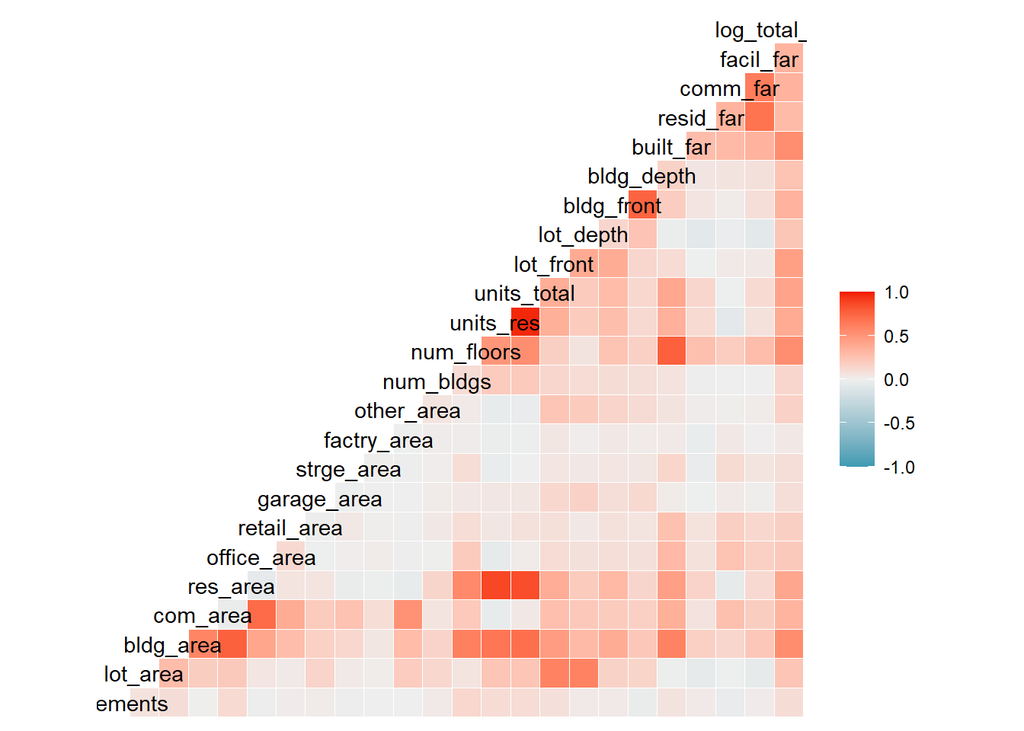

Based on this plot I identified which numerical variables correlated the most with the target variable. I put together three lists of them based on the level of correlation with the target variable: high, medium and low.

As for the categorical variables I calculated the conditional means of the target variable for different categories of all the variables. Then I put together two lists for them: one where the conditional means varied more across categories and one where they varied less.

### b. Separate training and test sets

I randomly split the dataset into two parts: a training set and a test set. They contained 30% and 70% of the observations respectively.

### c. Linear regression with 10-fold cross validation

I estimated OLS models with 10-fold cross validation and different sets of predictors. In the table below I present the results of the best 4 models.

Performance comparison of OLS models

|  | CV RMSE |
| --- | --- |
| OLS 1 (level) | 0.71 |
| OLS 2 (level) | 0.70 |
| OLS 3 (log) | 0.63 |
| OLS 4 (log) | 0.53 |

OLS 1 was estimated using the levels of the highly correlated numerical variables and the categorical ones for which the conditional mean of the target variable varied more. OLS 2 used the same predictors plus the numerical ones which were moderately correlated with the target variable. OLS 3 used the same predictor set as OLS 1, however all the numerical variables were logarithmically transformed. Finally, OLS 4 used the same set of predictors as OLS 2 with all the numerical variables transformed to logs. Based on the cross-validated RMSE-s we can conclude that OLS 4 has the highest predictive power and that functional forms really matter when estimating an OLS model.

### d. Penalized linear models

Next up, I estimated three types of penalized models: Ridge, LASSO and ELastic Net. The best ridge model used the same predictors as the OLS 4 model. The best LASSO and elastic net models, however, used a broader predictor set which also contained those categorical variables where the conditional mean of the target variable did not vary that much across categories. The table below shows the predictive performance of the final models for each type.

Performance comparison of OLS and penalized models

|  | CV RMSE |
| --- | --- |
| OLS | 0.53 |
| Ridge | 0.53 |
| LASSO | 0.52 |
| Elastic Net | 0.52 |

Based on the RMSE values we can conclude that the LASSO and the Elastic Net models are a tiny bit better than the OLS and the Ridge models. However, the difference is very small.

### e. Simplest model which is still good enough

For the two best penalized models - LASSO, and ELastic Net - I also tried the ‘oneSE’ method to find simpler models which are still good enough. I estimated both models with the same predictor sets as before.

The table below shows the parameters for the original and the oneSE LASSO models. We can see that the lambda parameter is twice as big for the oneSE model than for the original one. This means that more coefficients are shrunk to zero (the num_coefs column shows this), therefore the resulting model is simpler than before. However, the RMSE of the new model is almost the same as before.

Difference between original and 1 SE LASSO models

|  | alpha | lambda | num_coef |
| --- | --- | --- | --- |
| LASSO | 1 | 5e-04 | 200 |
| LASSO 1 SE | 1 | 1e-03 | 189 |

As for the Elastic Net model we can see that the alpha parameter significantly decreased, while the lambda significantly increased for the oneSE model. This means that the penalty for the sum of the squared coefficients is smaller, therefore they are not shrunk as much towards zero as in the original model. However, at the same time because of the higher lambda parameter the penalty for the sum of the absolute values of coefficients is higher. Indeed, the number of coefficients is lower by one for the oneSE model.

Difference between original and 1 SE Elastic Net models

|  | alpha | lambda | num_coef |
| --- | --- | --- | --- |
| Elastic Net | 0.8 | 0.001 | 192 |
| Elastic Net 1 SE | 0.1 | 0.010 | 191 |

### f. PCA for the linear model

After centering and scaling my variables I estimated a linear model with principal components as its explanatory variables. The optimal number of principal components was estimated to be 55, however the RMSE value was 0.648 which is larger than that of the simple linear model. This means that PCA did not improve the fit.

### g. PCA for penalized models

I estimated penalized models with PCA to see if it improves their fit. I used the same predictor sets for the models as before. The table below summarizes the RMSE values for the three models.

Performance comparison of penalized models with PCA

|  | CV RMSE |
| --- | --- |
| Ridge with PCA | 0.62 |
| LASSO with PCA | 0.59 |
| Elastic Net with PCA | 0.59 |

Based on this we can conclude that PCA did not manage to improve the fit of any of the models. The previous RMSE values were all lower. This could be the case because when we use PCA we actually lose part of the information that the variables contained before due to dimension reduction.

### h. Evaluate best model on test set

I chose the LASSO model estimated with the oneSE method as my best model. The reasons for this were that it had the lowest cross-validated RMSE and it was simpler than the normal LASSO model. I evaluated the model on the test set and got 0.536 for the RMSE which is very close to the cross-validated one which was 0.52.

# 2. Clustering on the USArrests dataset

### a. Data pre-processing steps before clustering

The variables need to be standardized before performing clustering because clustering uses distance measures and these are influenced by units of measurement. Therefore I standardized all my variables as a first step.

### b. Determine K

To determine the number of clusters I used `NbClust` which calculates several indexes and then uses majority voting to determine the optimal number of clusters. Based on this method the best number of clusters was 2.

### c. Cluster observations and plot them

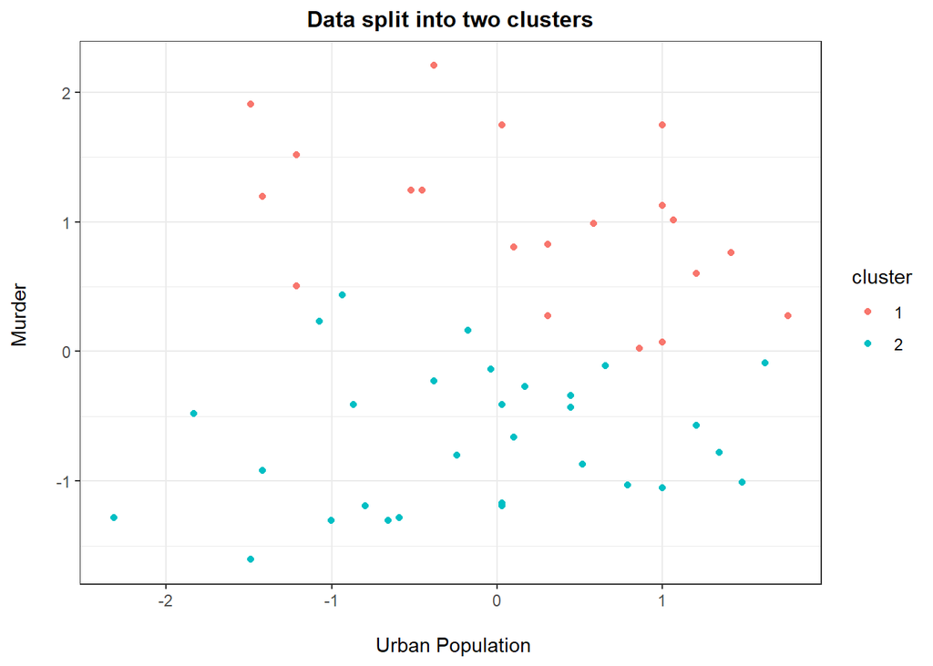

The second plot shows the observations grouped into three clusters suggested by the elbow method. The number of murders for states in the first cluster is lower on average than for the ones in the third cluster. The urban population of states in the first cluster is smaller in general than for states in the second cluster.

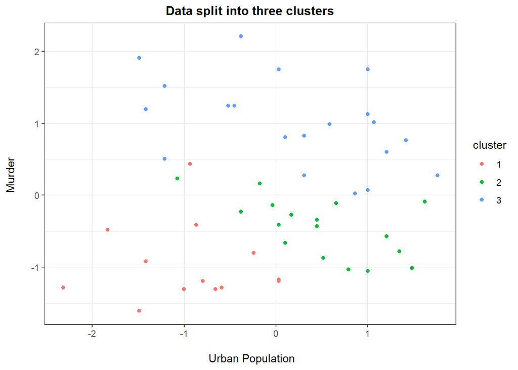

### d. Perform and plot PCA

The plot below shows the clustering of the points determined by the first two principal components. Here, compared to the clustering carried out in the previous exercise the borders between clusters are more straightforward. The clusters can be separated by vertical lines on the plot therefore we can see the rotation induced by PCA. If we assign the cluster labels from the previous exercise to the points we got from PCA the result is exactly the same.

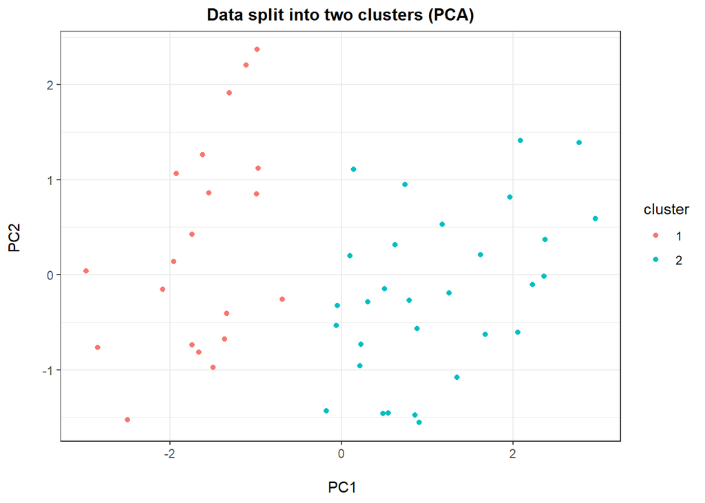

# 3. PCA of high-dimensional data

### a. Perform PCA on the data with scaling features

I used the `prcomp` function to perform PCA on the scaled genes data.

### b. Visualize data points in the space of the first two principal components

From the plot we can conclude that observations are sharply separated along the first principal component. If we look at it closer we can see that this distinction is actually between healthy and non-healthy individuals.

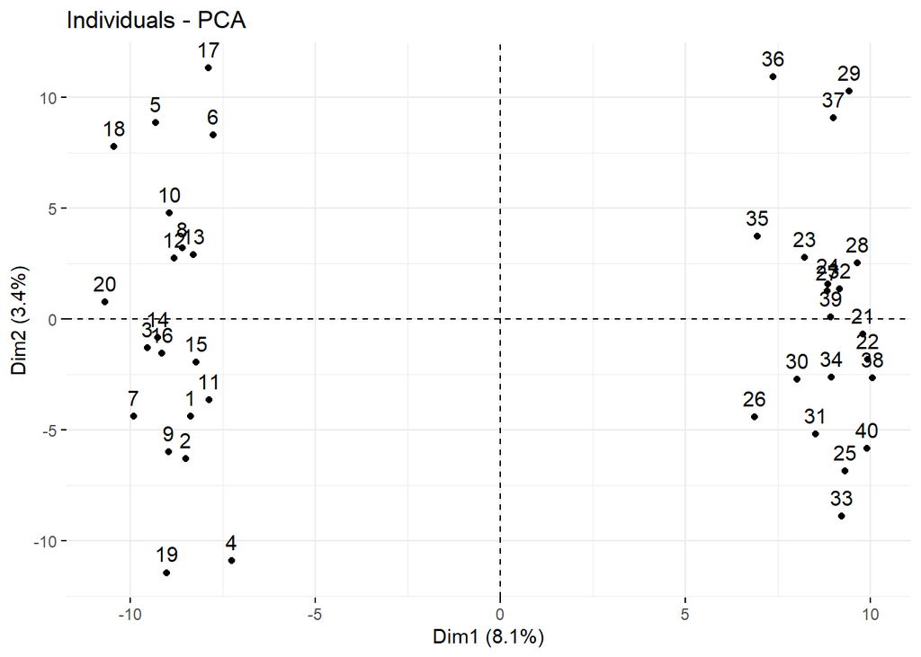

### c. Which individual features can matter the most in separating diseased from healthy?

To answer the question first I extracted the features which had the highest loadings (in absolute value) for PC1. It turned out that the top two features were genes V589 and V502. Therefore I plotted the original observations along these two features which can be seen below.

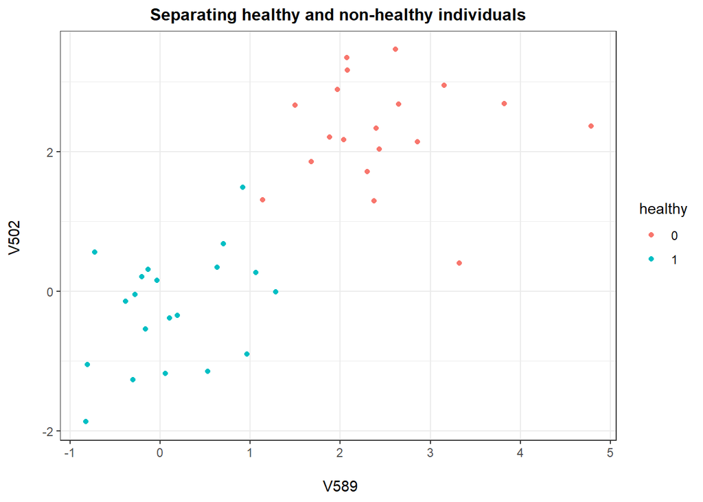

Based on this plot we can conclude that healthy individuals tend to have lower values for both V589 and V502, while non-healthy ones have higher values for both of them.